# lab5

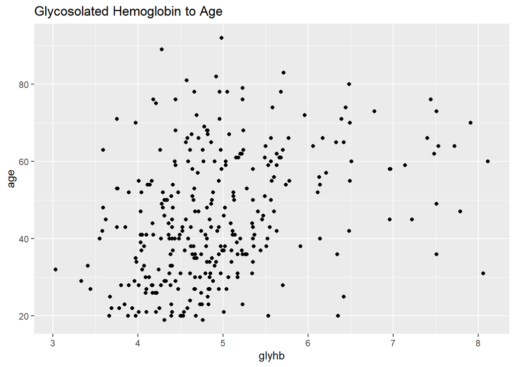

```r
   glyhb_star %>%  ggplot(aes(glyhb,age)) + geom_point() + labs(title = "Glycosolated Hemoglobin to Age")
```

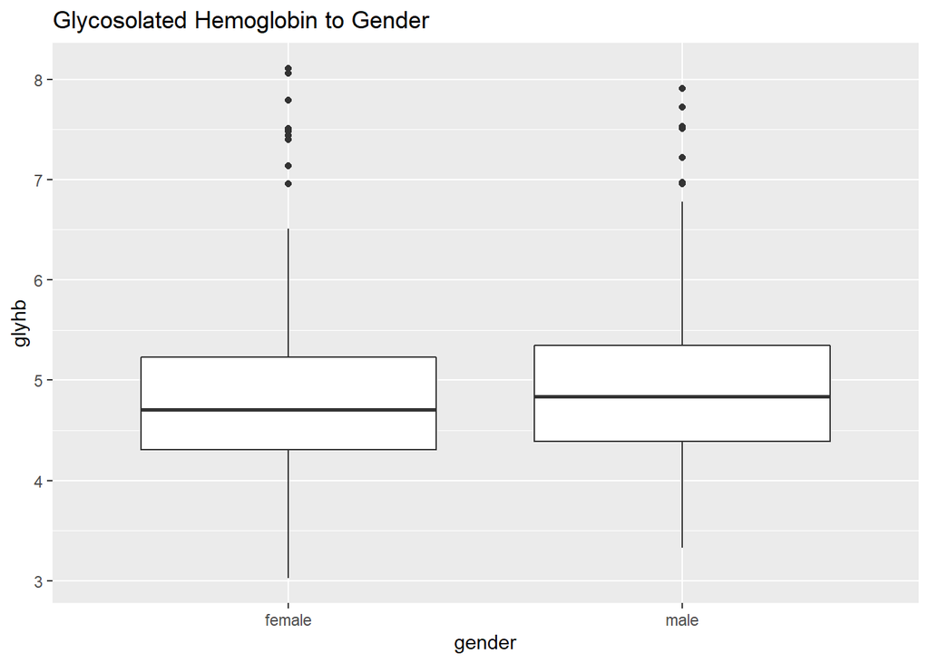

```r
   glyhb_star %>%  ggplot(aes(gender,glyhb)) + geom_boxplot() + labs(title = "Glycosolated Hemoglobin to Gender")
```

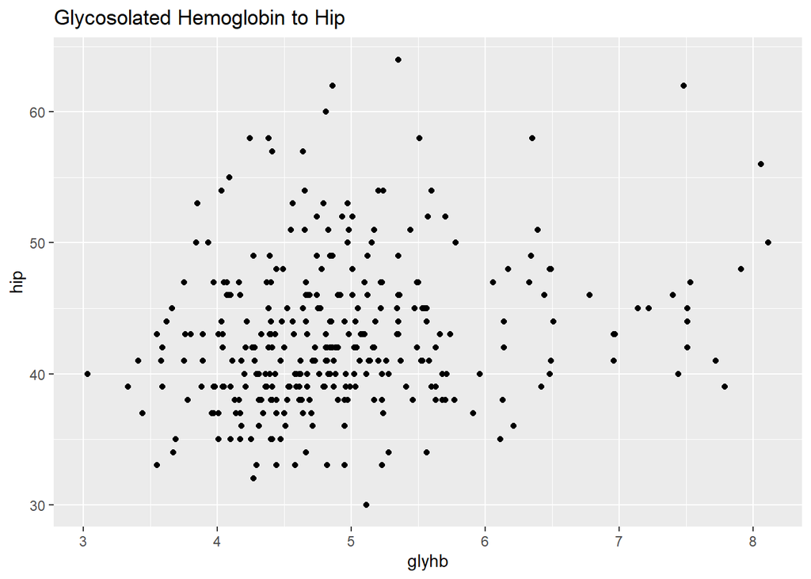

```r
   glyhb_star %>%  ggplot(aes(glyhb,hip)) + geom_point() + labs(title = "Glycosolated Hemoglobin to Hip")
```

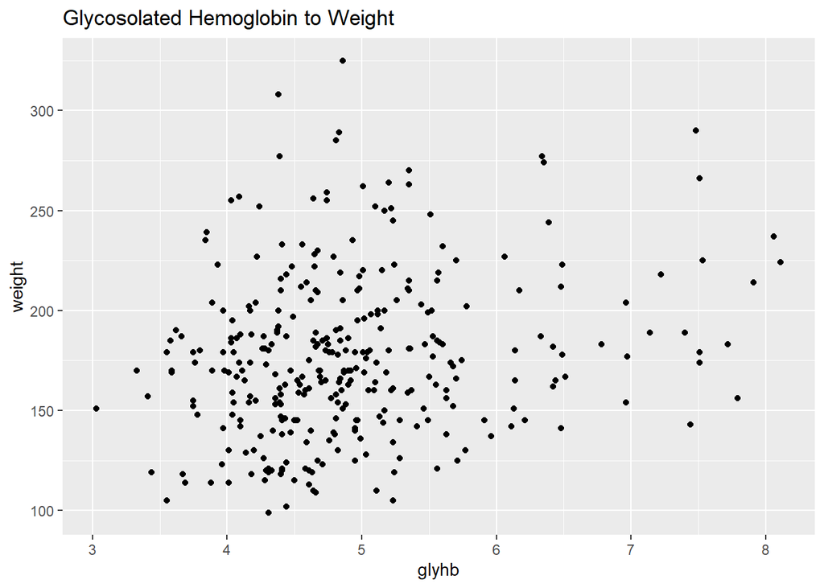

```r
   glyhb_star %>%  ggplot(aes(glyhb,weight)) + geom_point() + labs(title = "Glycosolated Hemoglobin to Weight")
```

Looking at these scatter plots, we can see that gender has little effect, but the rest of the variables have a weak positive relationship.

The following is a given graph that was asked to be improved upon.

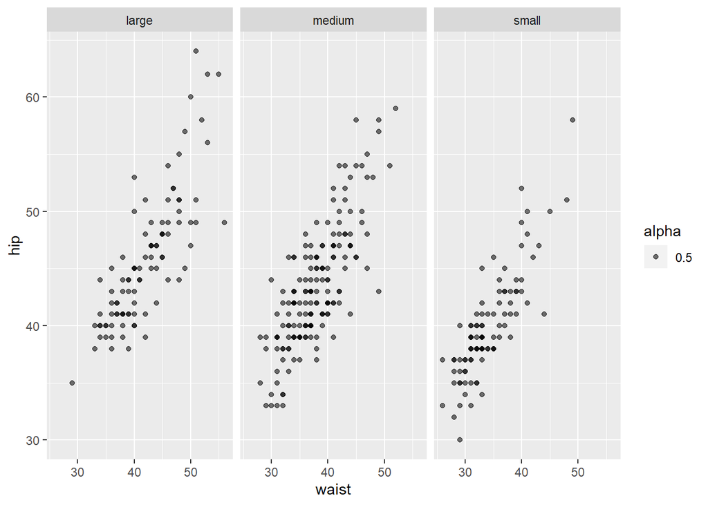

```r
ggplot(diabetes_clean,aes(y=hip,x=waist,alpha=0.5)) + geom_point() + facet_wrap(~frame)
```

One option to improve upon it is to instead create boxplots that seperates the waists into ranges.

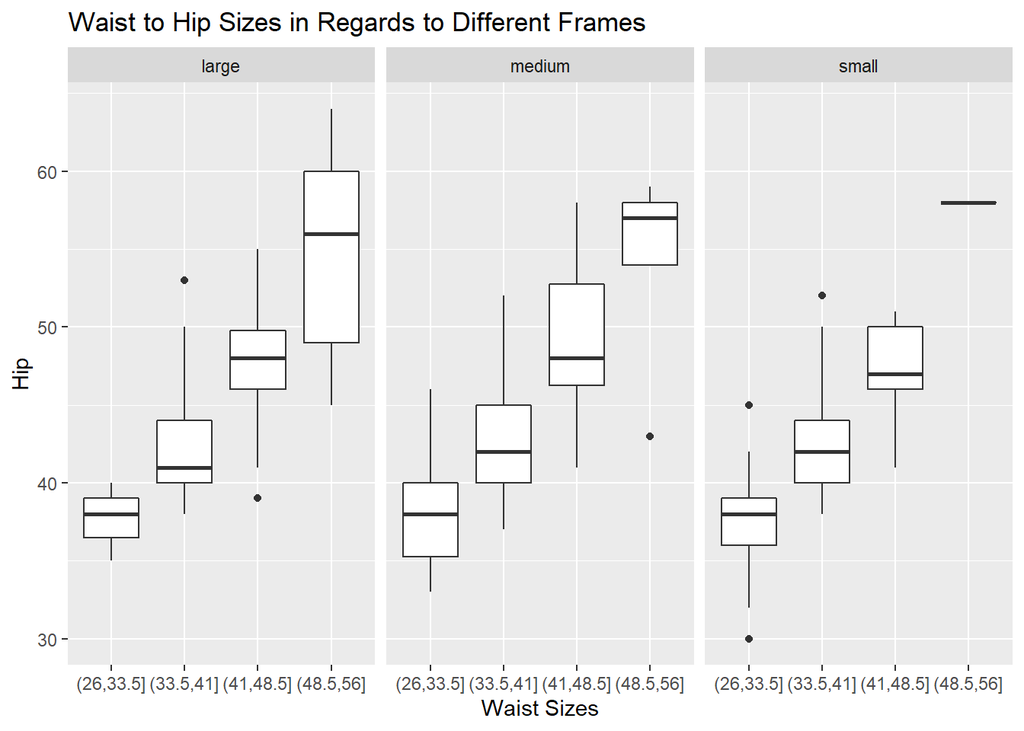

```r
diabetes_clean$waist2 = cut(diabetes_clean$waist,4)

ggplot(diabetes_clean,aes(y=hip,x=waist2)) + geom_boxplot() + facet_wrap(~frame) + labs(x = "Waist Sizes", y = "Hip", title = "Waist to Hip Sizes in Regards to Different Frames")
```

Another option is to use hollow points with jitter.

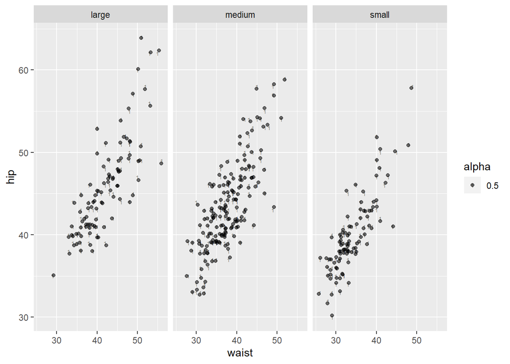

```r
ggplot(diabetes_clean,aes(y=hip,x=waist,alpha=0.5)) + geom_point(shape = "1") + geom_jitter() + facet_wrap(~frame)
```